# World Happiness Report 2005-2020

Divij Pherwani & Mert Camur

# Introduction

The project aims to create a reusable report with the same structure of the data. The report will include exploratory data analysis and basic modeling. The report will do the same analysis when the input data is changed. However, input data should be in the same structure as the initial input data.

A test data will be created from initial data and the reusability that is mentioned above will be tested with this data.

The following link is the dataset that is considered for this project: https://www.kaggle.com/ajaypalsinghlo/world-happiness-report-2021

The data includes 149 countries and their region. Also, it includes econometric values for each country.

# Data

## Description of the dataset

The World Happiness Report is a landmark survey of the state of global happiness . The report continues to gain global recognition as governments, organizations and civil society increasingly use happiness indicators to inform their policy-making decisions. Leading experts across fields – economics, psychology, survey analysis, national statistics, health, public policy and more – describe how measurements of well-being can be used effectively to assess the progress of nations. The reports review the state of happiness in the world today and show how the new science of happiness explains personal and national variations in happiness.

Number of data points for each region

```
## .
##         Central and Eastern Europe Commonwealth of Independent States
##                                225                                170
##                          East Asia        Latin America and Caribbean
##                                 82                                279
##       Middle East and North Africa              North America and ANZ
##                                211                                 58
##                         South Asia                     Southeast Asia
##                                 84                                116
##                 Sub-Saharan Africa                     Western Europe
##                                390                                271
```

Displaying Table in an interactive way using Shiny

| ï..Country.name | year | Life.Ladder | Log.GDP.per.capita | Social.support | Healthy.life.expectancy.at.birth | Freedom.to.make.life.choices | Generosity | Perceptions.of.corruption | Positive.affect | Negative.affect | Regional.indicator |
| --- | --- | --- | --- | --- | --- | --- | --- | --- | --- | --- | --- |
| Afghanistan | 2014 | 3.131 | 7.718 | 0.526 | 52.88 | 0.509 | 0.104 | 0.871 | 0.532 | 0.375 | South Asia |
| Afghanistan | 2015 | 3.983 | 7.702 | 0.529 | 53.2 | 0.389 | 0.08 | 0.881 | 0.554 | 0.339 | South Asia |
| Afghanistan | 2016 | 4.22 | 7.697 | 0.559 | 53 | 0.523 | 0.042 | 0.793 | 0.565 | 0.348 | South Asia |
| Afghanistan | 2017 | 2.662 | 7.697 | 0.491 | 52.8 | 0.427 | -0.121 | 0.954 | 0.496 | 0.371 | South Asia |
| Afghanistan | 2008 | 3.724 | 7.37 | 0.451 | 50.8 | 0.718 | 0.168 | 0.882 | 0.518 | 0.258 | South Asia |
| Afghanistan | 2011 | 3.832 | 7.62 | 0.521 | 51.92 | 0.496 | 0.162 | 0.731 | 0.611 | 0.267 | South Asia |
| Afghanistan | 2012 | 3.783 | 7.705 | 0.521 | 52.24 | 0.531 | 0.236 | 0.776 | 0.71 | 0.268 | South Asia |
| Afghanistan | 2013 | 3.572 | 7.725 | 0.484 | 52.56 | 0.578 | 0.061 | 0.823 | 0.621 | 0.273 | South Asia |
| Afghanistan | 2019 | 2.375 | 7.697 | 0.42 | 52.4 | 0.394 | -0.108 | 0.924 | 0.351 | 0.502 | South Asia |
| Afghanistan | 2018 | 2.694 | 7.692 | 0.508 | 52.6 | 0.374 | -0.094 | 0.928 | 0.424 | 0.405 | South Asia |

[output cut: 1876 more lines]

## Exploratory Data Analysis

The user selected year is 2009 and the user selected region is/are mentioned below.

```
##  [1] "South Asia"                         "Central and Eastern Europe"
##  [3] "Middle East and North Africa"       "Latin America and Caribbean"
##  [5] "Commonwealth of Independent States" "North America and ANZ"
##  [7] "Western Europe"                     "Sub-Saharan Africa"
##  [9] "Southeast Asia"                     "East Asia"
```

The user selected Log.GDP.per.capita = TRUE, Social.support = TRUE, Healthy.life.expectancy.at.birth = TRUE, Generosity = TRUE and Perceptions.of.corruption = TRUE for ML model.

Final user selected attributes are mentioned below.

```
## [1] "Log.GDP.per.capita"               "Social.support"
## [3] "Healthy.life.expectancy.at.birth" "Generosity"
## [5] "Perceptions.of.corruption"
```

Number of unique years

```
## [1] 16
```

Number of unique country names

```
## [1] 149
```

Summary of the data set

```
##  ï..Country.name         year       Life.Ladder    Log.GDP.per.capita
##  Length:1886        Min.   :2005   Min.   :2.375   Min.   : 6.635
##  Class :character   1st Qu.:2010   1st Qu.:4.660   1st Qu.: 8.482
##  Mode  :character   Median :2013   Median :5.405   Median : 9.476
##                     Mean   :2013   Mean   :5.488   Mean   : 9.388
##                     3rd Qu.:2017   3rd Qu.:6.299   3rd Qu.:10.370
##                     Max.   :2020   Max.   :8.019   Max.   :11.648
##                                                    NA's   :24
##  Social.support  Healthy.life.expectancy.at.birth Freedom.to.make.life.choices
##  Min.   :0.291   Min.   :32.30                    Min.   :0.2580
##  1st Qu.:0.752   1st Qu.:59.06                    1st Qu.:0.6500
##  Median :0.837   Median :65.32                    Median :0.7660
##  Mean   :0.815   Mean   :63.59                    Mean   :0.7448
##  3rd Qu.:0.907   3rd Qu.:68.70                    3rd Qu.:0.8570
##  Max.   :0.987   Max.   :77.10                    Max.   :0.9850
##  NA's   :9       NA's   :51                       NA's   :30
##    Generosity       Perceptions.of.corruption Positive.affect  Negative.affect
##  Min.   :-0.33500   Min.   :0.0350            Min.   :0.3220   Min.   :0.0830
##  1st Qu.:-0.11600   1st Qu.:0.6920            1st Qu.:0.6288   1st Qu.:0.2060
##  Median :-0.02800   Median :0.8040            Median :0.7235   Median :0.2580
##  Mean   :-0.00129   Mean   :0.7479            Mean   :0.7114   Mean   :0.2675
##  3rd Qu.: 0.09075   3rd Qu.:0.8738            3rd Qu.:0.8000   3rd Qu.:0.3190
##  Max.   : 0.69800   Max.   :0.9830            Max.   :0.9440   Max.   :0.5910
##  NA's   :76         NA's   :104               NA's   :18       NA's   :13
##  Regional.indicator
##  Length:1886
##  Class :character
##  Mode  :character
##
##
##
##
```

Description of the dataset

```
## # A tibble: 10 x 26
##    variable     n    na     mean     sd se_mean   IQR skewness kurtosis      p00
##    <chr>    <int> <int>    <dbl>  <dbl>   <dbl> <dbl>    <dbl>    <dbl>    <dbl>
##  1 year      1886     0  2.01e+3 4.20   0.0966  7      -0.144   -1.09   2005
##  2 Life.La~  1886     0  5.49e+0 1.11   0.0256  1.64    0.0733  -0.703     2.38
##  3 Log.GDP~  1862    24  9.39e+0 1.14   0.0264  1.89   -0.320   -0.871     6.64
##  4 Social.~  1877     9  8.15e-1 0.116  0.00268 0.155  -1.08     1.06      0.291
##  5 Healthy~  1835    51  6.36e+1 7.42   0.173   9.64   -0.781    0.0517   32.3
##  6 Freedom~  1856    30  7.45e-1 0.141  0.00326 0.207  -0.625   -0.102     0.258
##  7 Generos~  1810    76 -1.29e-3 0.163  0.00384 0.207   0.821    0.847    -0.335
##  8 Percept~  1782   104  7.48e-1 0.187  0.00444 0.182  -1.51     1.87      0.035
##  9 Positiv~  1868    18  7.11e-1 0.106  0.00246 0.171  -0.369   -0.592     0.322
## 10 Negativ~  1873    13  2.67e-1 0.0829 0.00192 0.113   0.610    0.284     0.083
## # ... with 16 more variables: p01 <dbl>, p05 <dbl>, p10 <dbl>, p20 <dbl>,
## #   p25 <dbl>, p30 <dbl>, p40 <dbl>, p50 <dbl>, p60 <dbl>, p70 <dbl>,
## #   p75 <dbl>, p80 <dbl>, p90 <dbl>, p95 <dbl>, p99 <dbl>, p100 <dbl>
```

Checking Normality of all the available factors

```
## # A tibble: 9 x 4
##   vars                             statistic  p_value sample
##   <chr>                                <dbl>    <dbl>  <dbl>
## 1 Life.Ladder                          0.986 2.20e-12   1886
## 2 Log.GDP.per.capita                   0.966 1.16e-20   1886
## 3 Social.support                       0.919 1.27e-30   1886
## 4 Healthy.life.expectancy.at.birth     0.943 6.02e-26   1886
## 5 Freedom.to.make.life.choices         0.963 1.64e-21   1886
## 6 Generosity                           0.961 1.24e-21   1886
## 7 Perceptions.of.corruption            0.845 1.20e-38   1886
## 8 Positive.affect                      0.974 5.14e-18   1886
## 9 Negative.affect                      0.976 5.01e-17   1886
```

## Preparing Analysis Plots

### Checking correlation between all factors

```
##                                  Life.Ladder Log.GDP.per.capita Social.support
## Life.Ladder                        1.0000000        0.786583448     0.70551242
## Log.GDP.per.capita                 0.7865834        1.000000000     0.69477870
## Social.support                     0.7055124        0.694778697     1.00000000
## Healthy.life.expectancy.at.birth   0.7405709        0.838507170     0.60654459
## Freedom.to.make.life.choices       0.5169521        0.353509950     0.41369273
## Generosity                         0.1926334       -0.002463189     0.07200483
## Perceptions.of.corruption         -0.4344032       -0.340763134    -0.22774379
## Positive.affect                    0.5205893        0.281338114     0.42535424
## Negative.affect                   -0.2801623       -0.205018015    -0.37808438
##                                  Healthy.life.expectancy.at.birth
## Life.Ladder                                            0.74057093
## Log.GDP.per.capita                                     0.83850717
## Social.support                                         0.60654459
## Healthy.life.expectancy.at.birth                       1.00000000
## Freedom.to.make.life.choices                           0.37758561
## Generosity                                             0.02270024
## Perceptions.of.corruption                             -0.32302995
## Positive.affect                                        0.30462666
## Negative.affect                                       -0.12374734
##                                  Freedom.to.make.life.choices   Generosity
## Life.Ladder                                         0.5169521  0.192633374
## Log.GDP.per.capita                                  0.3535099 -0.002463189
## Social.support                                      0.4136927  0.072004829
## Healthy.life.expectancy.at.birth                    0.3775856  0.022700239
## Freedom.to.make.life.choices                        1.0000000  0.327845069
## Generosity                                          0.3278451  1.000000000
## Perceptions.of.corruption                          -0.4858125 -0.281059191
## Positive.affect                                     0.5944906  0.360383305
## Negative.affect                                    -0.2458433 -0.104763893
##                                  Perceptions.of.corruption Positive.affect
## Life.Ladder                                     -0.4344032       0.5205893
## Log.GDP.per.capita                              -0.3407631       0.2813381
## Social.support                                  -0.2277438       0.4253542
## Healthy.life.expectancy.at.birth                -0.3230299       0.3046267
## Freedom.to.make.life.choices                    -0.4858125       0.5944906
## Generosity                                      -0.2810592       0.3603833
## Perceptions.of.corruption                        1.0000000      -0.2955903
## Positive.affect                                 -0.2955903       1.0000000
## Negative.affect                                  0.2623683      -0.3573623
##                                  Negative.affect
## Life.Ladder                           -0.2801623
## Log.GDP.per.capita                    -0.2050180
## Social.support                        -0.3780844
## Healthy.life.expectancy.at.birth      -0.1237473
## Freedom.to.make.life.choices          -0.2458433
## Generosity                            -0.1047639
## Perceptions.of.corruption              0.2623683
## Positive.affect                       -0.3573623
## Negative.affect                        1.0000000
```

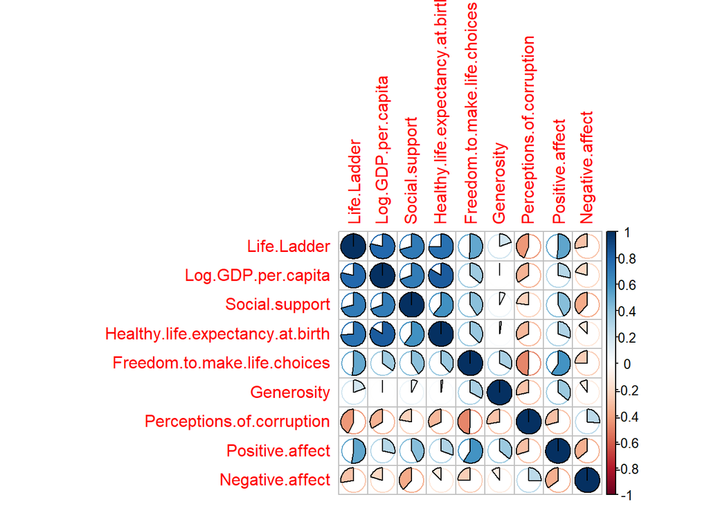

### Top & Bottom five for Happiness index of countries in 2009

#### Happiest

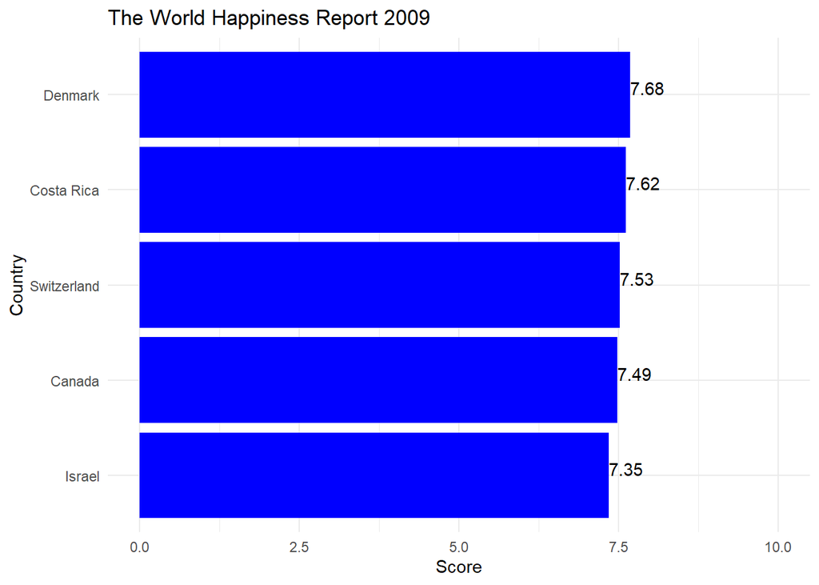

#### Unhappiest

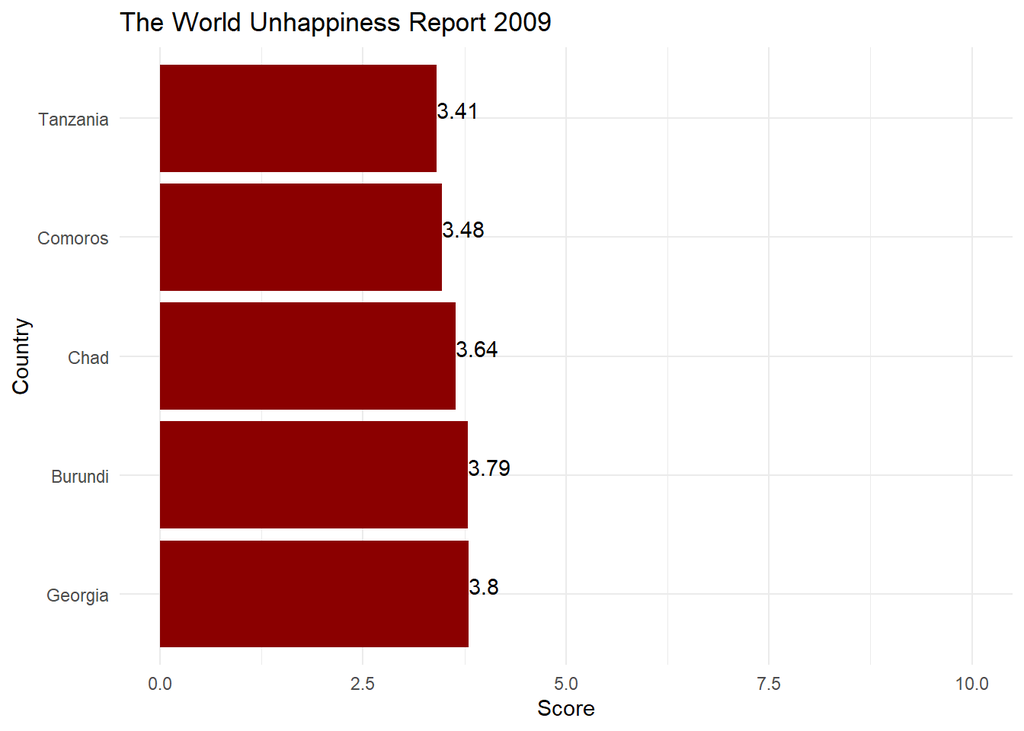

#### Comparison

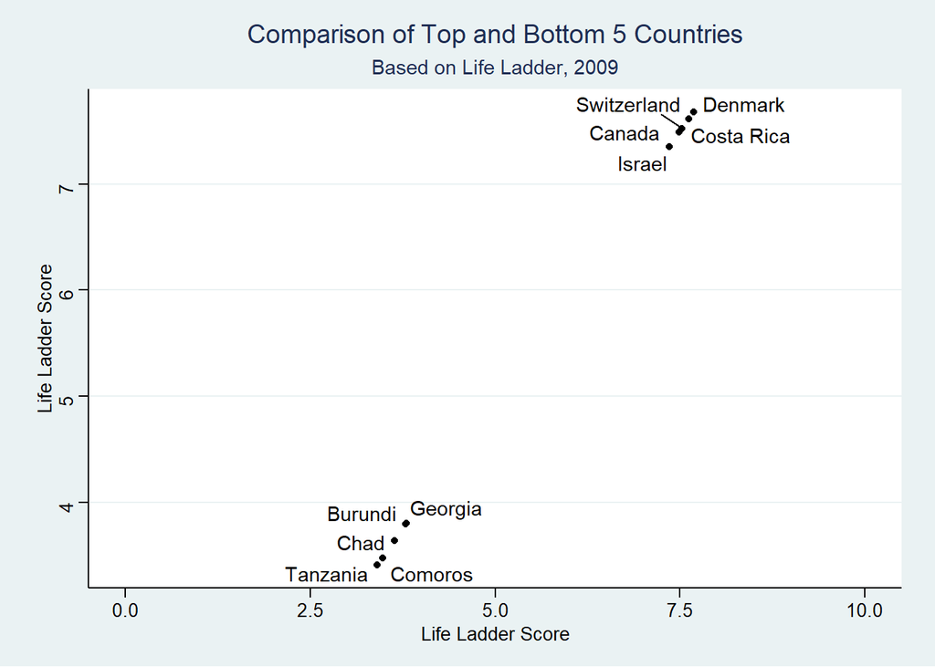

### Top & Bottom five for Happiness index of regions in 2009

#### Happiest

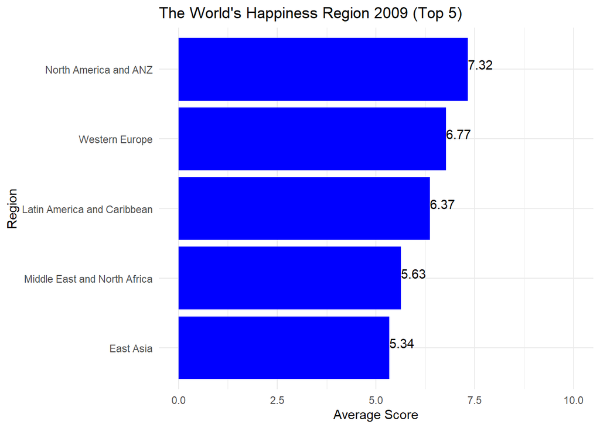

#### Unhappiest

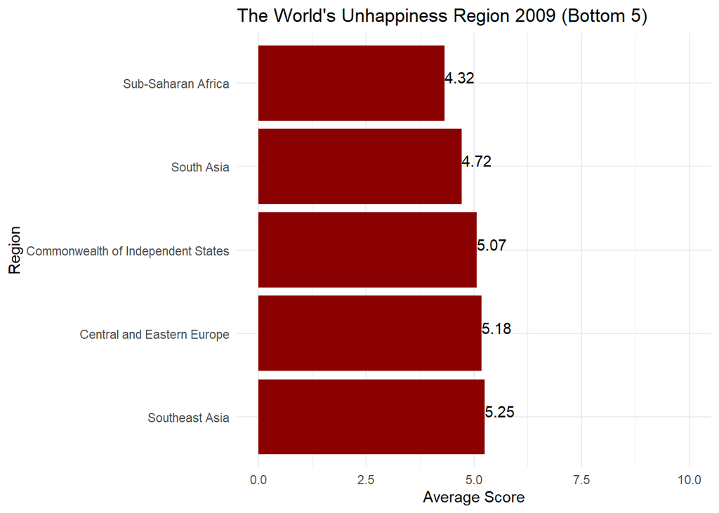

#### Comparison

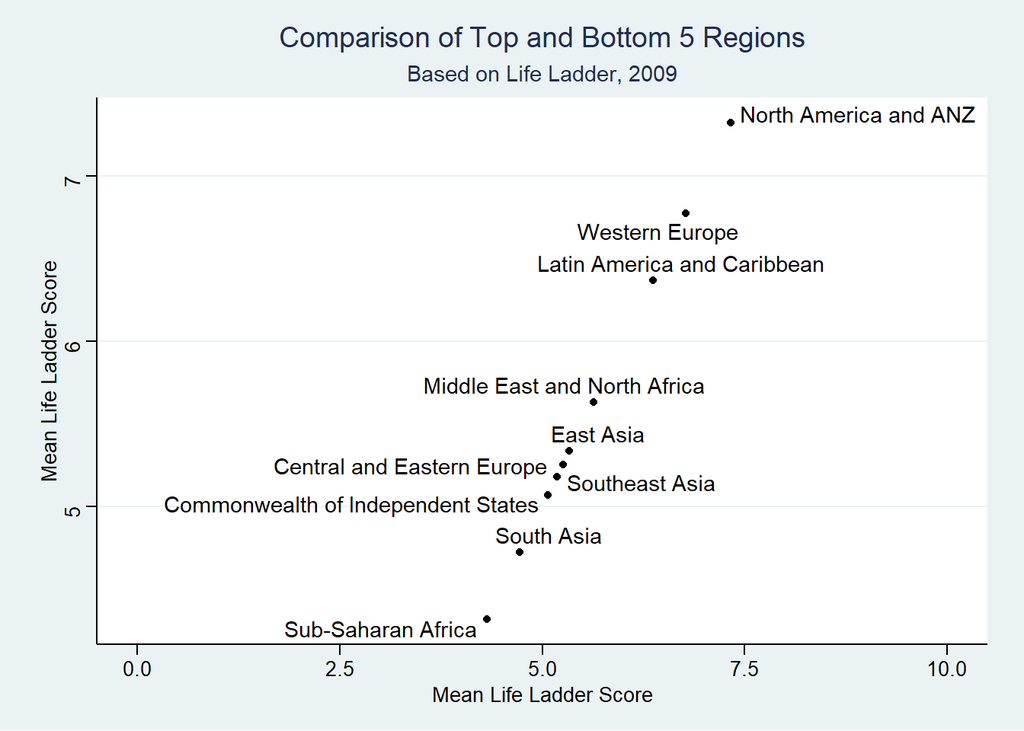

# Linear Regression Model

**The Linear Regression Model is built for data points for region - Select All**

The table of the filtered data

| year | ï..Country.name | Life.Ladder | Regional.indicator | Negative.affect | Positive.affect | Log.GDP.per.capita | Social.support | Healthy.life.expectancy.at.birth | Generosity | Perceptions.of.corruption |
| --- | --- | --- | --- | --- | --- | --- | --- | --- | --- | --- |
| 2014 | Afghanistan | 3.131 | South Asia | 0.375 | 0.532 | 7.718 | 0.526 | 52.88 | 0.104 | 0.871 |
| 2010 | Afghanistan | 4.758 | South Asia | 0.275 | 0.618 | 7.647 | 0.539 | 51.6 | 0.121 | 0.707 |
| 2010 | Albania | 5.269 | Central and Eastern Europe | 0.3 | 0.648 | 9.303 | 0.733 | 66.4 | -0.172 | 0.726 |
| 2014 | Algeria | 6.355 | Middle East and North Africa | 0.177 | 0.626 | 9.335 | 0.818 | 65.14 | -0.00129281767955801 | 0.747851290684624 |
| 2016 | Argentina | 6.427 | Latin America and Caribbean | 0.312 | 0.842 | 10.051 | 0.883 | 68.4 | -0.192 | 0.851 |
| 2010 | Argentina | 6.441 | Latin America and Caribbean | 0.211 | 0.846 | 10.066 | 0.927 | 67.3 | -0.126 | 0.855 |
| 2008 | Armenia | 4.652 | Commonwealth of Independent States | 0.385 | 0.521 | 9.256 | 0.709 | 65 | -0.215 | 0.876 |
| 2015 | Australia | 7.309 | North America and ANZ | 0.21 | 0.79 | 10.779 | 0.952 | 72.7 | 0.332 | 0.357 |
| 2020 | Australia | 7.137 | North America and ANZ | 0.205 | 0.769 | 10.76 | 0.937 | 74.2 | 0.21 | 0.491 |
| 2014 | Austria | 6.95 | Western Europe | 0.17 | 0.78 | 10.882 | 0.899 | 71.96 | 0.118 | 0.567 |

[output cut: 183 more lines]

After removing categorical variables, we keep the numeric variables for regression. Table of data to be input in regression function.

| Life.Ladder | Negative.affect | Positive.affect | Log.GDP.per.capita | Social.support | Healthy.life.expectancy.at.birth | Generosity | Perceptions.of.corruption |
| --- | --- | --- | --- | --- | --- | --- | --- |
| 3.131 | 0.375 | 0.532 | 7.718 | 0.526 | 52.88 | 0.104 | 0.871 |
| 4.758 | 0.275 | 0.618 | 7.647 | 0.539 | 51.6 | 0.121 | 0.707 |
| 5.269 | 0.3 | 0.648 | 9.303 | 0.733 | 66.4 | -0.172 | 0.726 |
| 6.355 | 0.177 | 0.626 | 9.335 | 0.818 | 65.14 | -0.00129281767955801 | 0.747851290684624 |
| 6.427 | 0.312 | 0.842 | 10.051 | 0.883 | 68.4 | -0.192 | 0.851 |
| 6.441 | 0.211 | 0.846 | 10.066 | 0.927 | 67.3 | -0.126 | 0.855 |
| 4.652 | 0.385 | 0.521 | 9.256 | 0.709 | 65 | -0.215 | 0.876 |
| 7.309 | 0.21 | 0.79 | 10.779 | 0.952 | 72.7 | 0.332 | 0.357 |
| 7.137 | 0.205 | 0.769 | 10.76 | 0.937 | 74.2 | 0.21 | 0.491 |
| 6.95 | 0.17 | 0.78 | 10.882 | 0.899 | 71.96 | 0.118 | 0.567 |

[output cut: 183 more lines]

Correlation plot for the final factors involved in regression

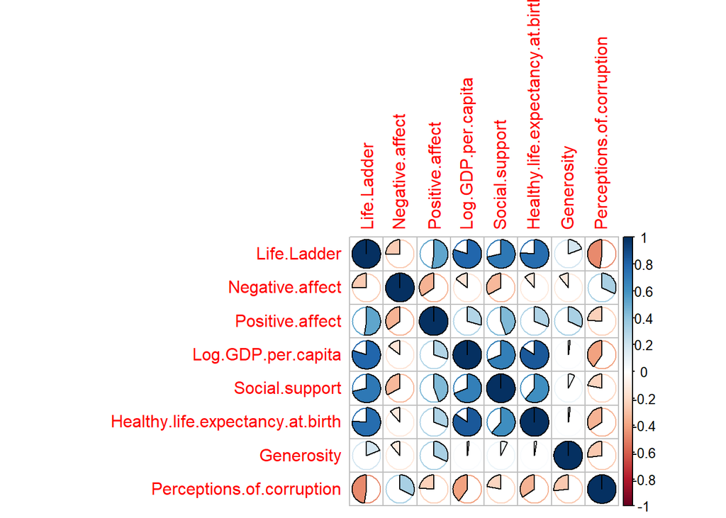

Regression Metrics

Number of factors in regression

```
## [1] 8
```

Backward selection of selected factors

```
## Linear Regression with Backwards Selection
##
## 193 samples
##   7 predictor
##
## No pre-processing
## Resampling: Bootstrapped (25 reps)
## Summary of sample sizes: 193, 193, 193, 193, 193, 193, ...
## Resampling results across tuning parameters:
##
##   nvmax  RMSE       Rsquared   MAE
##   1      0.6967007  0.6202717  0.5742633
##   2      0.6152938  0.7035537  0.4939639
##   3      0.6049628  0.7134083  0.4796959
##   4      0.5835424  0.7305366  0.4563495
##   5      0.5599848  0.7521605  0.4418398
##   6      0.5541961  0.7571739  0.4374516
##   7      0.5555715  0.7560741  0.4378730
##   8      0.5555715  0.7560741  0.4378730
##
## RMSE was used to select the optimal model using the smallest value.
## The final value used for the model was nvmax = 6.
```

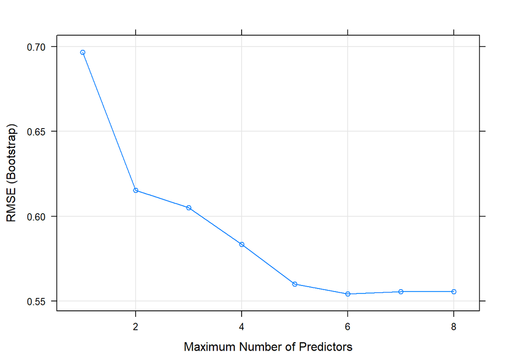

Simple Linear Regression Model

```
##
## Call:
## lm(formula = Life.Ladder ~ ., data = DataForML)
##
## Residuals:
##      Min       1Q   Median       3Q      Max
## -1.64201 -0.31010  0.03297  0.34208  1.58835
##
## Coefficients:
##                                  Estimate Std. Error t value Pr(>|t|)
## (Intercept)                      -2.12886    0.49579  -4.294 2.83e-05 ***
## Negative.affect                   0.34859    0.52716   0.661 0.509270
## Positive.affect                   2.13748    0.41954   5.095 8.57e-07 ***
## Log.GDP.per.capita                0.30826    0.06816   4.523 1.09e-05 ***
## Social.support                    2.05333    0.48738   4.213 3.93e-05 ***
## Healthy.life.expectancy.at.birth  0.03371    0.00907   3.717 0.000267 ***
## Generosity                        0.36389    0.25360   1.435 0.153007
## Perceptions.of.corruption        -0.92997    0.23467  -3.963 0.000106 ***
## ---
## Signif. codes:  0 '***' 0.001 '**' 0.01 '*' 0.05 '.' 0.1 ' ' 1
##
## Residual standard error: 0.5185 on 185 degrees of freedom
## Multiple R-squared:  0.788,  Adjusted R-squared:  0.7799
## F-statistic: 98.21 on 7 and 185 DF,  p-value: < 2.2e-16
```

**Formula for Regression : Life.Ladder ~ Negative.affect+Positive.affect+Log.GDP.per.capita+Social.support+Healthy.life.expectancy.at.birth+Generosity+Perceptions.of.corruption**

Plots for regression

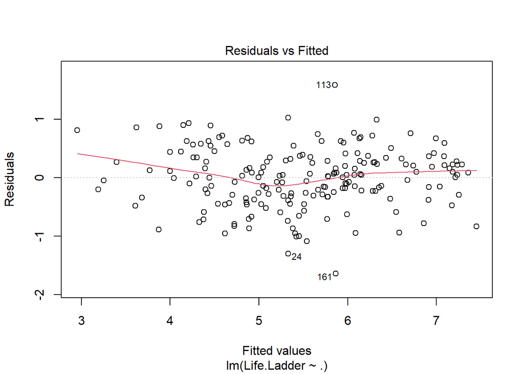

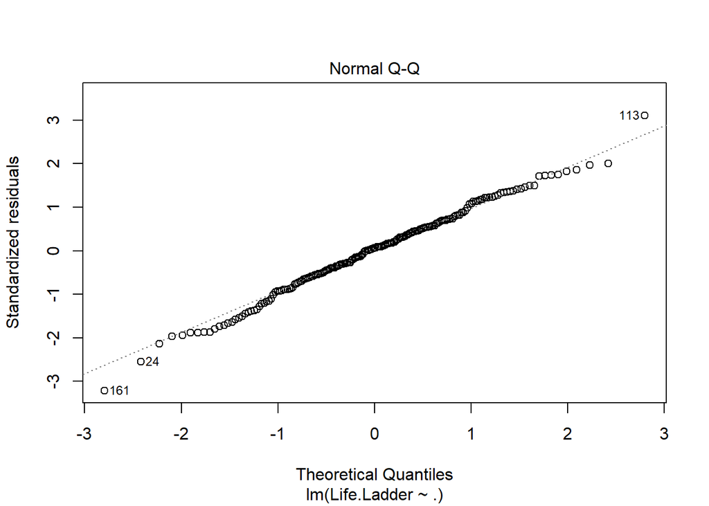

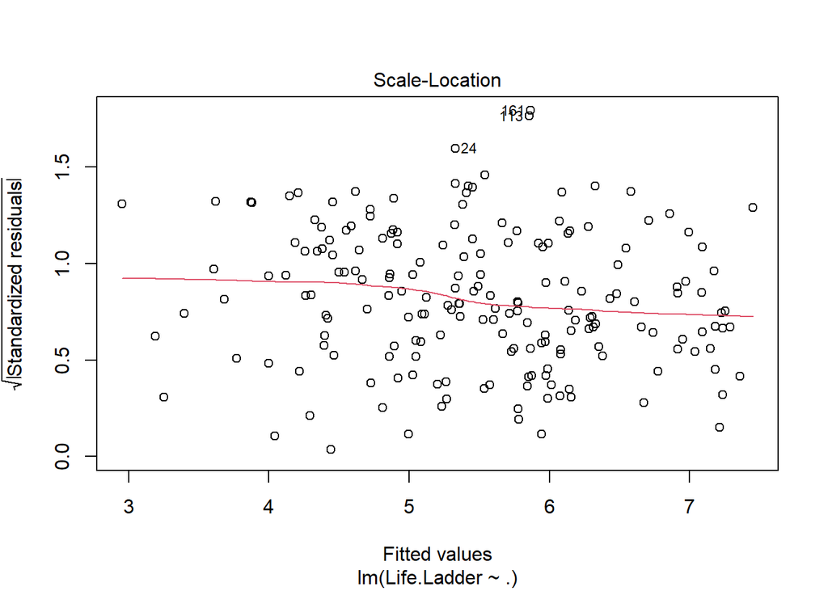

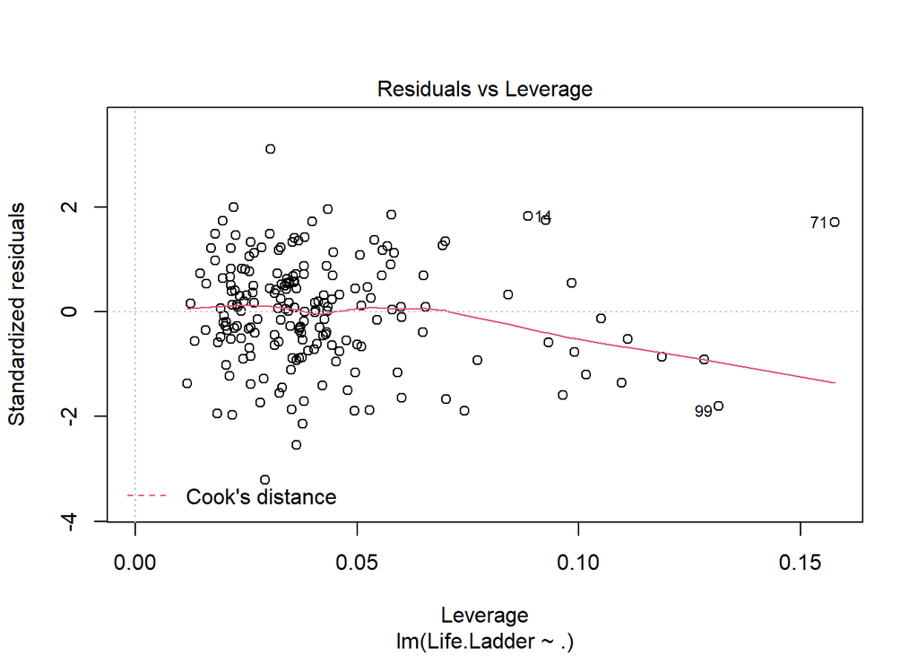